# RNA-seq HOMEWORK

Aleksandra Kurowska

January 27, 2024

## 1. Compare “Results from JCI Insight” vs “Results derived from your own analysis”

[figure not shown]

“Severe COVID-19 disease is associated with dysregulation of the myeloid compartment during acute infection. Survivors frequently experience long-lasting sequelae, but little is known about the eventual persistence of this immune alteration”

In the study, they evaluate a cohort of mild to critical patients during acute or convalescent phases of the disease. Their results demonstrate that severe COVID-19 infection has a profound impact on the differentiation status and function of circulating monocytes, during both the acute and the convalescent phases, in a completely distinct manner. This could have important implications for our understanding of short- and long-term COVID-19–related morbidity.

### PCA results

#### “Results from JCI Insight”

In the paper they observed a clear separation between samples from acute and healthy controls upon principal component analysis. COVID-19 patients from early recovery stage formed a distinct cluster, while late recovery stage patients were found to be embedded within the control group. See the figure below.

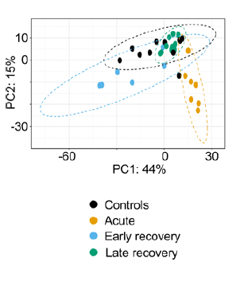

#### “Results derived from your own analysis”

After re-analyzing the data on my own, we can observe a very similar samples separation. Moreover, the percentages of variance explained for PC1 and PC2 are almost the same as in the original analysis. See the figure below.

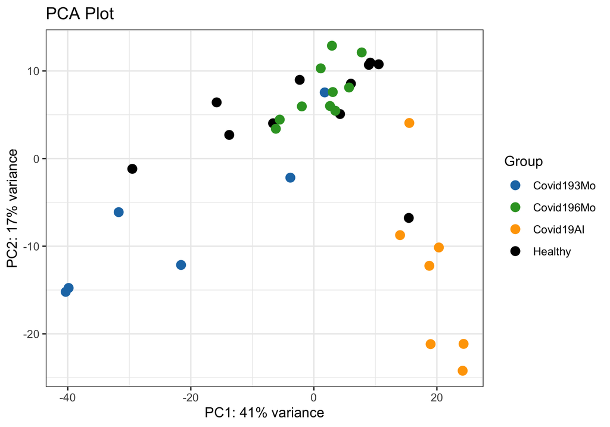

## Differential expression (DE) analysis

### “Results from JCI Insight”

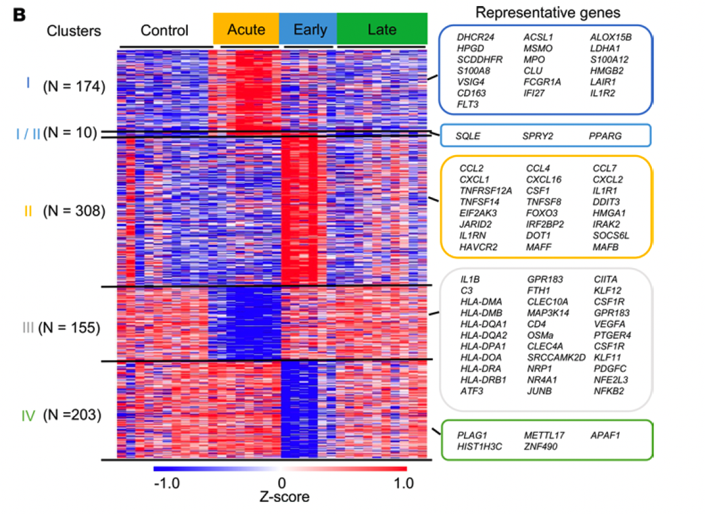

#### Early recovery stage

In patients in the early recovery period, they have identified 521 differentially expressed genes as compared with controls, including up-regulation of important intracellular immunomodulatory proteins and transcription factors: **PPARG**, **FOSL1**, **MAFB**, **ATF4**, **MAFF**, **FOXO3**.

#### Late recovery stage

For the pateints at the latter stage, they have identified hardly any differentially expressed genes.

#### All stages DE comparison

Additionally they have found a very small overlap between differentially expressed genes in the acute stage and in the recovery groups, indicating that the transcriptomic program induced by the acute infection is not persistent.

### “Results derived from your own analysis”

Plot preseting most important differential genes identified in the paper.

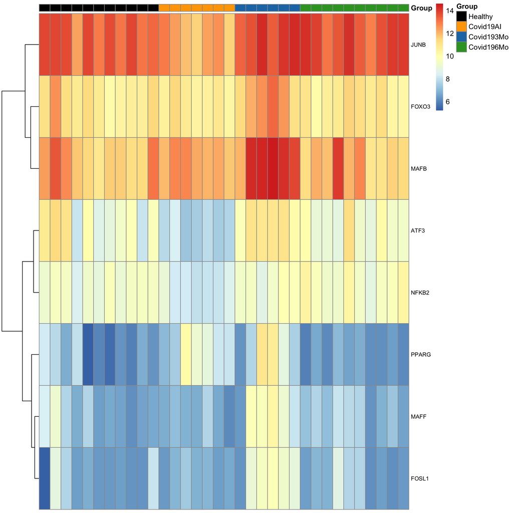

#### Acute samples

In our own analysis of the data, we identified much more differentially expressed genes. Using the same cutoff thersholds as in the paper (a fold change [FC] > 2 and a FDR < 0.05) I have found 1002 statistically differentially expressed genes in acute samples compared with controls. The result is almost 3x higher than presented in the paper. This difference may be originated due to specific parameters used in the analysis. However, the authors haven’t precisely specified the protocol, they have followed. Whereas, I used the default settings. Nonetheless, consistent with the publication, we observe decreased expression of genes related to key immune pathways, such as **JUNB**, **ATF3**, **NFkB2**.

#### Early recovery stage

For early stage samples we identify 815 differentially expressed genes, which is much more compared with the paper. However, consistent with the publication, we see similar up-regulation of **PPARG**, **FOSL1**, **MAFB**, **MAFF**, **FOXO3**.

#### Late recovery stage

As discovered in the paper, hardy any differentially genes were found in our analysis in the late recovery stage.

#### All stages DE comparison

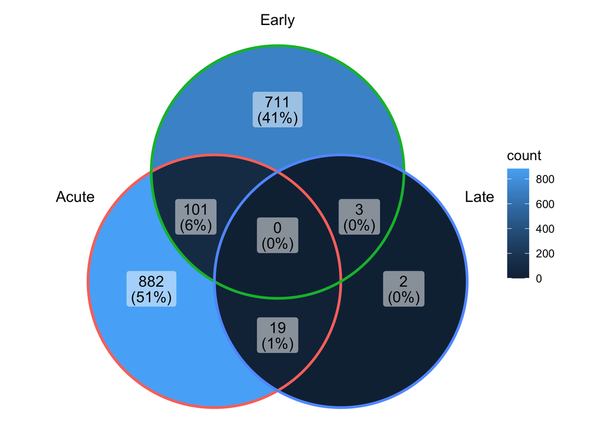